# Metodos Computacionais: Bootstrap

## Estimação da correlação entre 2 amostras

Nesse segundo exemplo, iremos trabalhar com dados de um evento que está prestes a acontecer novamente: A Copa do Mundo. Onde iremos estimar a correlação entre a quantidade de gols na edição realizada com o ano na qual ela ocorreu, ou seja, observar se existe algum tipo de relação no ano com a quantidade de gols

Para isso, utilizaremos o conjunto de dados “WorldCupMatches.csv” disponivel em:(https://www.kaggle.com/datasets/abecklas/fifa-world-cup)

```r
  wc_data=read_csv("WorldCupMatches.csv")%>%
        select("Year","Home Team Goals","Away Team Goals","MatchID")%>%
        rename(Year="Year",Home_Team_Goals="Home Team Goals",Away_Team_Goals="Away Team Goals")%>%
        group_by(Year)%>%
        summarise(sum(Home_Team_Goals),sum(Away_Team_Goals))%>%
        rename(Home_Team_Goals="sum(Home_Team_Goals)",Away_Team_Goals="sum(Away_Team_Goals)")%>%
        mutate(Goals = rowSums(across(c(Home_Team_Goals, Away_Team_Goals))))%>%
        drop_na()%>%
        ungroup()
```

Copas do Mundo ocorrem em 4 em 4 anos, onde sua primeira realização foi em 1930. Assim, até 2014 tivemos apenas 20 eventos, um numero baixo populacional. Para estudarmos a estimativa do correlação do ano com a quantidade de gols, utilizaremos o metodo Bootstrap de reamostragem para o aumento no nuemro de observações, onde iremos analisar o intervalo de confiança das estimativas e sua qualidade

- 1. As primeiras linhas do conjunto de dados final:

```r
head(wc_data)%>%
  kbl() %>%
  kable_paper("hover", full_width = F)
```

| Year | Home_Team_Goals | Away_Team_Goals | Goals |
| --- | --- | --- | --- |
| 1930 | 59 | 11 | 70 |
| 1934 | 48 | 22 | 70 |
| 1938 | 61 | 23 | 84 |
| 1950 | 69 | 19 | 88 |
| 1954 | 109 | 31 | 140 |
| 1958 | 88 | 38 | 126 |

- 2. Analisando os dados de forma exploratória:

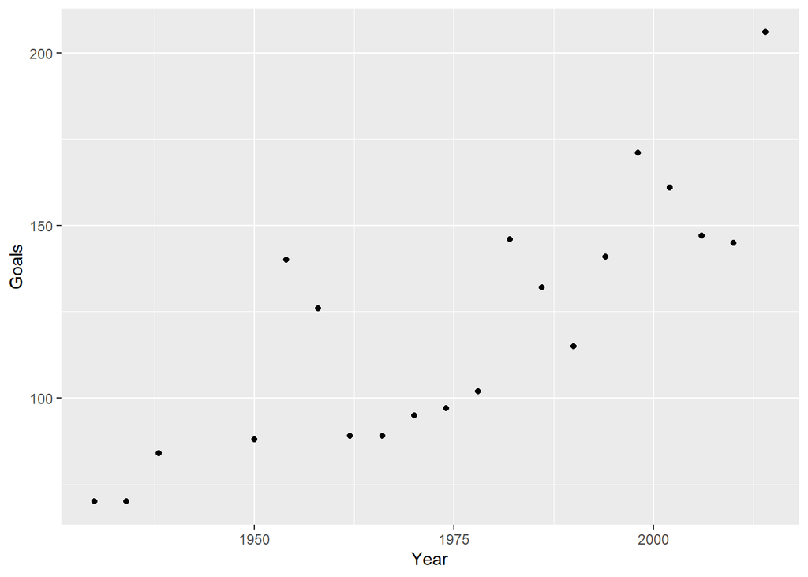

```r
fig=ggplot(data=wc_data,aes(x=Year,y=Goals))+
    geom_point()
fig
```

- 3. Calculando os valores da correlação via Pearson e via Spearman

```r
wc_cor_pearson=cor(wc_data$Year,wc_data$Goals)
wc_cor_spearman=cor(wc_data$Year,wc_data$Goals,method = 'spearman')

data_correlation_wc=data.frame(Pearson=wc_cor_pearson,Spearman=wc_cor_spearman)

data_correlation_wc%>%
 kbl() %>%
  kable_classic_2(full_width = F)
```

| Pearson | Spearman |
| --- | --- |
| 0.8245587 | 0.8713321 |

- 4. Calculando os valores da correlação via Pearson e via Spearman apartir das amostras Bootstrap e observando o intervalo de confiança calculado

```r
wc_boot_cor_pearson=boot_corr_samples(as.data.frame(wc_data),col_index1=1,col_index2=4)
wc_boot_corr_pearson_interval=boot_interval_conf(wc_boot_cor_pearson,0.95)

wc_boot_cor_spearman=boot_corr_samples(as.data.frame(wc_data),col_index1=1,col_index2=4,by='spearman')
wc_boot_cor_spearman_interval=boot_interval_conf(wc_boot_cor_spearman,0.95)
```

```r
wc_boot_cor_total=rbind(wc_boot_corr_pearson_interval,wc_boot_cor_spearman_interval)
rownames(wc_boot_cor_total)=c("Pearson","Spearman")

wc_boot_cor_total%>%
  kbl() %>%
  kable_classic_2(full_width = F)
```

|  | Confidence | Bottom_lim | Upper_lim |
| --- | --- | --- | --- |
| Pearson | 0.95 | 0.6504034 | 0.9321293 |
| Spearman | 0.95 | 0.6579511 | 0.9711843 |

- 5. Observando a qualidade dos estimativas

```r
wc_cor_pearson_bootstrap_quality=boot_quality(wc_boot_cor_pearson,theta=wc_cor_pearson)
wc_cor_spearman_bootstrap_quality=boot_quality(wc_boot_cor_spearman,theta=wc_cor_spearman)

wc_boot_cor_quality=rbind(wc_cor_pearson_bootstrap_quality,wc_cor_spearman_bootstrap_quality)

rownames(wc_boot_cor_quality)=c("Pearson","Spearman")

wc_boot_cor_quality%>%
  kbl() %>%
  kable_classic_2(full_width = F)
```

|  | Bias | Var | M.S.E |
| --- | --- | --- | --- |
| Pearson | -0.0019690 | 0.0050784 | 0.0050823 |
| Spearman | -0.0184248 | 0.0069682 | 0.0073076 |

## Teste de hipotese para o valor da mediana de 2 amostras

Nesse ultimo caso seguiremos o exemplo dado pelo professor Fernando, no video [Aula de Laboratório - Exemplos de Boostrap no R - Parte 2](https://www.youtube.com/watch?v=V8vARWehxY8&t=1082s&ab_channel=Fernandofn). Onde queremos observar se a mediana do dos valores de milhas por galão entre carros automaticos e manuais são iguais

```r
mpg_cars_data=mtcars%>%
                  select(mpg,am)

mpg_manual_cars_data=mpg_cars_data%>%
                              filter(am==1)

mpg_automatic_cars_data=mpg_cars_data%>%
                              filter(am==0)
```

- 1. Realizando o teste de hipótese com as estimativas calculadas atraves das amostras via Bootstrap

```r
mpg_manual_cars_bootstrap_median=boot_sim(mpg_manual_cars_data[,1])%>%
                                                boot_stat(median)

mpg_automatic_cars_bootstrap_median=boot_sim(mpg_automatic_cars_data[,1])%>%
                                                boot_stat(median)

median_diference=mpg_manual_cars_bootstrap_median-mpg_automatic_cars_bootstrap_median

t.test(median_diference,alternative="two.sided")
```

```
##
##  One Sample t-test
##
## data:  median_diference
## t = 19.321, df = 99, p-value < 2.2e-16
## alternative hypothesis: true mean is not equal to 0
## 95 percent confidence interval:
##  6.239858 7.668142
## sample estimates:
## mean of x
##     6.954
```

Portanto, temos um p-valor baixíssimo e assim rejeitamos a hipotese nula, onde $H_0=$a mediana dos dados dos carros automaticos é igual a mediana dos carros manuais

Observando a qualidade das estimativas calculadas via Bootstrap, temos:

```r
mpg_manual_cars_bootstrap_quality=mpg_manual_cars_bootstrap_median%>%
                          boot_quality(theta=median(mpg_manual_cars_data$mpg))

mpg_automatic_cars_bootstrap_quality=mpg_automatic_cars_bootstrap_median%>%
                          boot_quality(theta=median(mpg_automatic_cars_data$mpg))

mpg_cars_bootstrap_quality=rbind(mpg_manual_cars_bootstrap_quality,mpg_automatic_cars_bootstrap_quality)
rownames(mpg_cars_bootstrap_quality)=c("Manual","Automatico")

mpg_cars_bootstrap_quality%>%
  kbl() %>%
  kable_classic_2(full_width = F)
```

|  | Bias | Var | M.S.E |
| --- | --- | --- | --- |
| Manual | 1.201 | 9.819494 | 11.261895 |
| Automatico | -0.253 | 1.498476 | 1.562485 |

Portanto, é possivel ver as estimativas da mediana dos carros automaticos apresentaram um Erro menor. Essa diferença pode ser explicada pelo tamanho amostral original, onde tinha-se apenas 13 carros manuais contra 19 carros automaticos

# Disponibilização do pacote

O pacote desenvolvido nesse trabalho chama-se: bootsimplyr, e está em fase inicial de desenvolvimento, e portanto ainda não possui uma versão disponível no CRAN.

No entanto, a versão de desenvolvimento do pacote já está disponível para download e pode ser instalada através do repositório no GitHub com:

```r
# install.packages("devtools")
devtools::install_github("Gustavo039/bootsimplyr")
```

Ou pode ser visitado atraves do link https://github.com/Gustavo039/bootsimplyr